# Part II - (Effects of Ford GoBike System Data Exploration Characteristics on Their Duration Seconds)

## by (Acheampong Andrews)

## Investigation Overview

> In this investigation, I wanted to look at the characteristics of GoBike that could be used to predict their duration seconds. The main focus was on the three variables of GoBike: bike_id, member_gender, and bike_share_for_all_trip.

## Dataset Overview

> This data set includes information about individual rides made in a bike-sharing system covering the greater San Francisco Bay area.

The start_time and end_time were object data type, I changed them to datetime data type and split the date and time into four variables start_time, end_time, start_date, and end_date. I also remove all the NAN values to make the dataset ready for analysis.

## Distribution of GoBike Duration Seconds

Duration second has a long-tailed distribution, with a lot of small time end, and few on the greatest time end. When plotted on a log-scale, the duration seconds distribution looks a normal distribution, with the peak between 20000 and 60000, and its slightly skewed to the right.

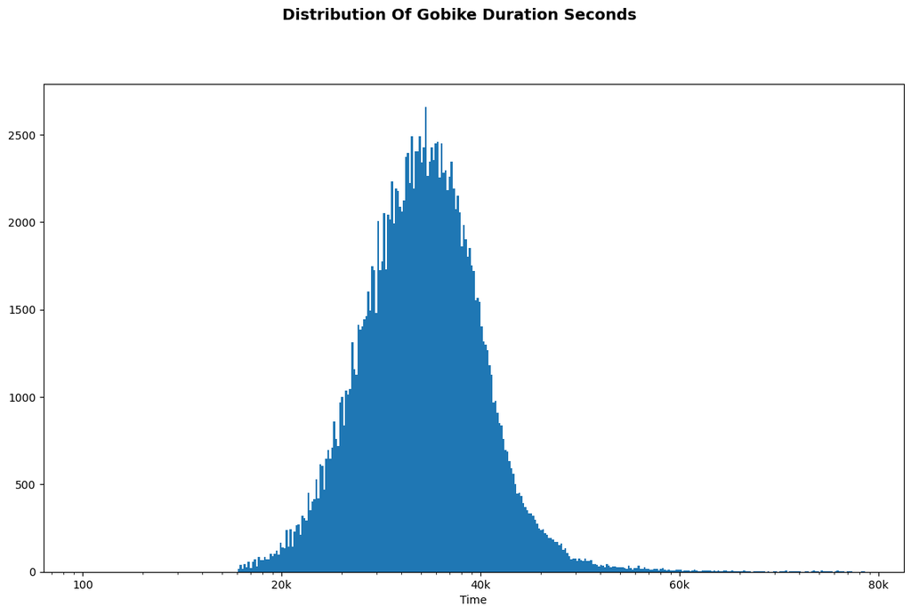

## Duration Seconds vs. member gender

> From the graph we can observe under the member gender column the male had the least duration second indcating the fasters, female being the second and the others has the least number of bike_id

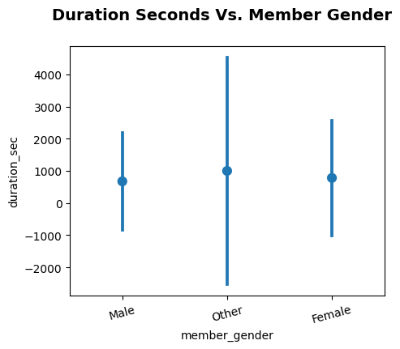

## Duration Seconds vs. (member gender and bike_share_for_all_trip)

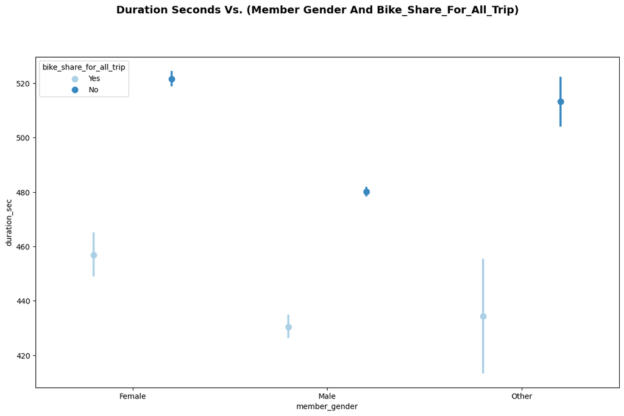